# **Understanding Prosper Loan Data Set**

*Uirá Caiado. April 7, 2015*

## Introduction

I have to tell the truth. Initially, the number of variables intimidated me. There are 113,937 rows in this data set and 81 columns (variables). It seems to come from Prosper website, a peer-to-peer [(P2P)](http://en.wikipedia.org/wiki/Peer-to-peer_lending) lending marketplace. I have already seen a brazilian website trying to do something similar in my country, but our “SEC” shut them off. Just financial companies can lend money here.

According to [wikipedia](http://en.wikipedia.org/wiki/Prosper_Marketplace#Loan_performance_prior_to_July_2009), the SEC imposed that Prosper had to cease their operations due to violations on [a piece of legislation](http://www.investopedia.com/terms/s/securitiesact1933.asp) that ensures transparency and try to avoid fraudulent activities in the american securities markets. The website took from November 2008 to July 2009 to resume their activities.

Bellow you can see the effect of this time closed:

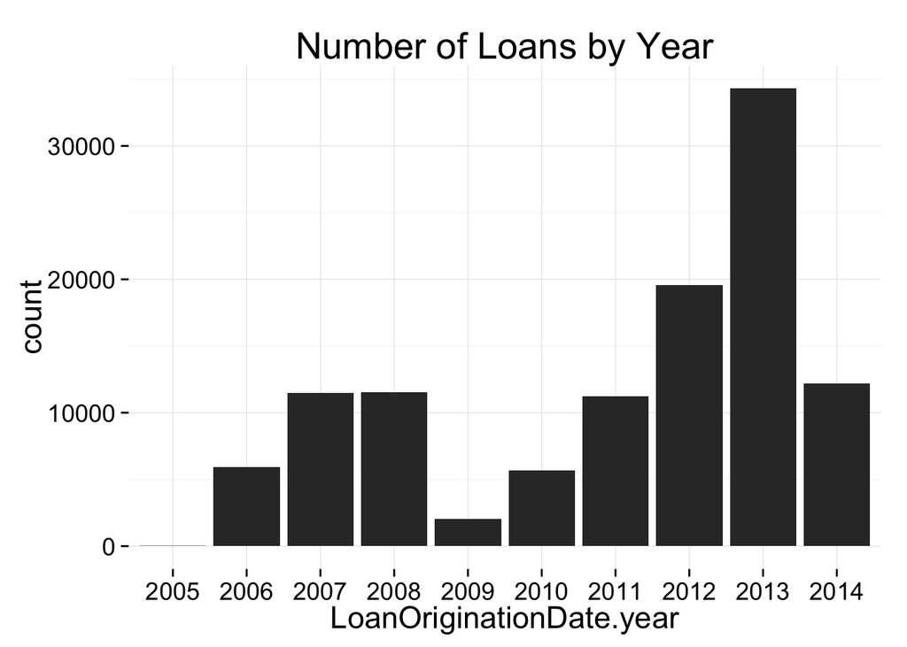

There are 6 variables in the data set just valid to loans originated after 2009 and I believe that they were created to comply regulatory rules. In general, they are all about how much interest have been payed and how risky each loan were. Looking at other variables, I can see that they are pretty diverse but they are all related to these two factors: risk and return.

There are variable explicit about risk measurements (what was the classification when the loan was took, the scores from Prosper), about how much was paid and earned, meta data of the loan (the size in money and duration, when and where it was originated), about the profile of the borrower (employment status, his income, his debts, what he intend to do with the money), how each loan was founded and so on.

As P2P lending is something new for me, I would like to understand how it works on United States and I will use this database to achieve that.

## Analysis

### Univariate Section

In Brazil, where I live, I would expect the total loans rise at some months of the year. Usually at the begining and the end of the year, when people travel, pay taxes and buy gifts. Let’s start looking at the amount of money borrowed by month in United States.

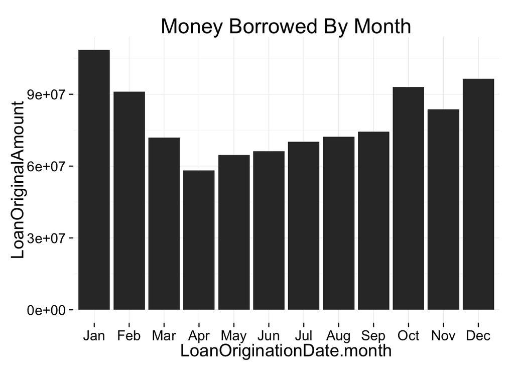

As expected, the amount of loans rises at first and last months of the year. Well, if there are more money borrowed on these periods, maybe the number of loans defaulted increases between them. To verify that, I have to use the ClosedDate variable and filter just the defaulted and chargedoff loans. Let’s see:

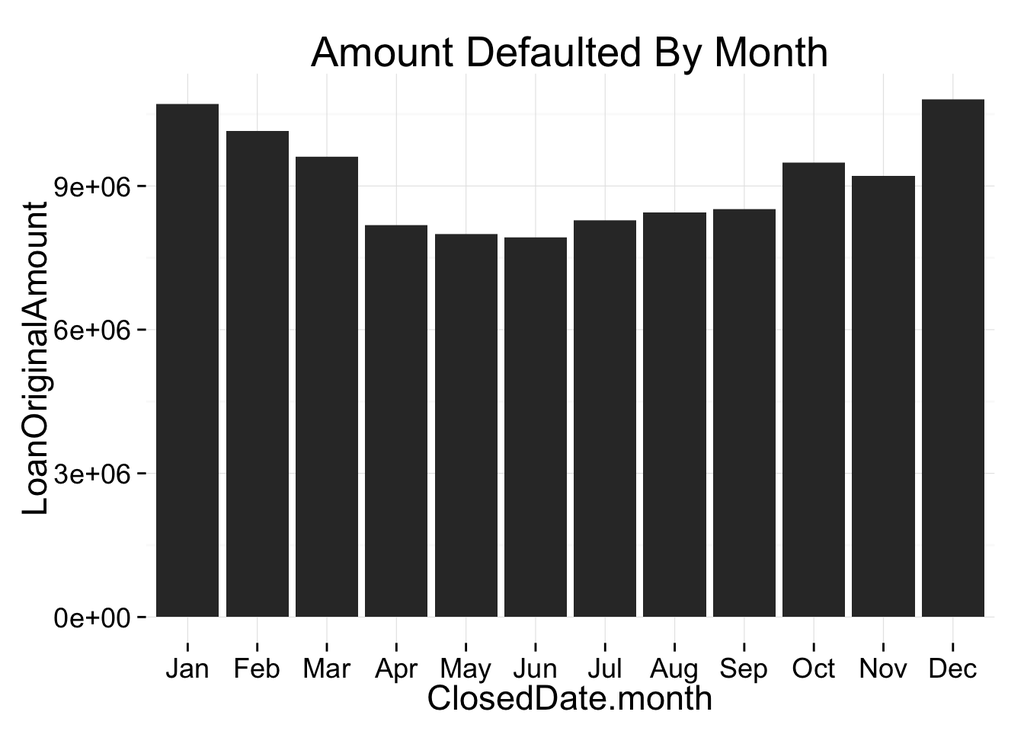

```
##
##              Cancelled   Chargedoff/Defaulted              Completed
##                   0.00                   0.15                   0.33
##                Current FinalPaymentInProgress          Past Due Date
##                   0.50                   0.00                   0.02
```

Thinking again, nobody would borrow money to pay back in the next couple of months, at least not in Brazil. Let’s see how many loans, percentually, were borrowed by duration:

```
##
##   12   36   60
## 0.01 0.77 0.22
```

It explains why the distributions of Defaulted/Chargedoff loans and the amount borrowed by month looks like the same. As people take loans on regular durations, 12, 36 and 60 months, the loans will ever due to the same month in different years.

How about the median of the loan? First, let’s see the quartiles of the value of each loan:

```
##    Min. 1st Qu.  Median    Mean 3rd Qu.    Max.
##    1000    4000    6500    8337   12000   35000
```

Wow…$ 1,000 to $35,000. It is a huge range. But it seems that the most of the loans are smaller, given that 50 % of the data set is up to $ 6500. Let’s take a close look at the loan original amount split by duration. I had to convert the variable “Term” to factor to make the chart bellow:

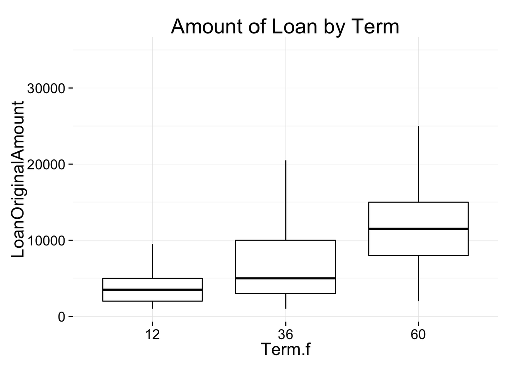

```r
theme_set(theme_minimal(17))

d$Term.f <- as.factor(d$Term)

ggplot(aes(x = Term.f, y = LoanOriginalAmount), data = d) +
  scale_color_brewer(type = 'div') +
  geom_boxplot(outlier.size = 0, color = "black") +
  ggtitle('Amount of Loan by Term')
```

It seems that the loan for each duration is something that I should not plot together. The distribution of each one is prety different.

Well, and how about the ineterest rate? The distribution differs at each term? First, let’s see the histogram of the interest paid:

```
##    Min. 1st Qu.  Median    Mean 3rd Qu.    Max.
##  0.0000  0.1340  0.1840  0.1928  0.2500  0.4975
```

```
## stat_bin: binwidth defaulted to range/30. Use 'binwidth = x' to adjust this.
```

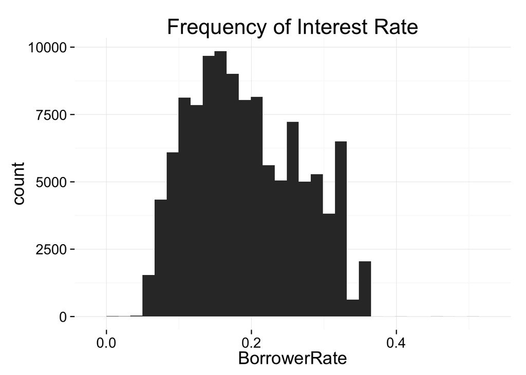

There is something different on the right tail. Let’s reduce the bin width to 0.5%

```
##    Min. 1st Qu.  Median    Mean 3rd Qu.    Max.
##  0.0000  0.1340  0.1840  0.1928  0.2500  0.4975
```

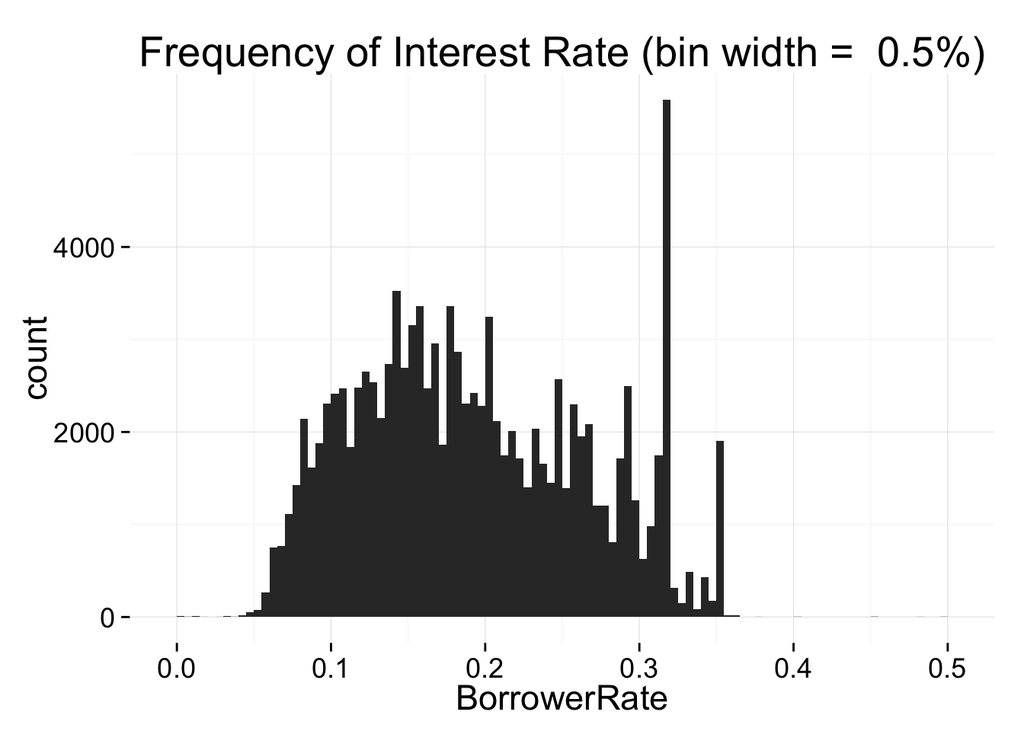

Definitely there is something different after 30% of annual interest rate. Let’s take a close look at the range between 30%-37%.

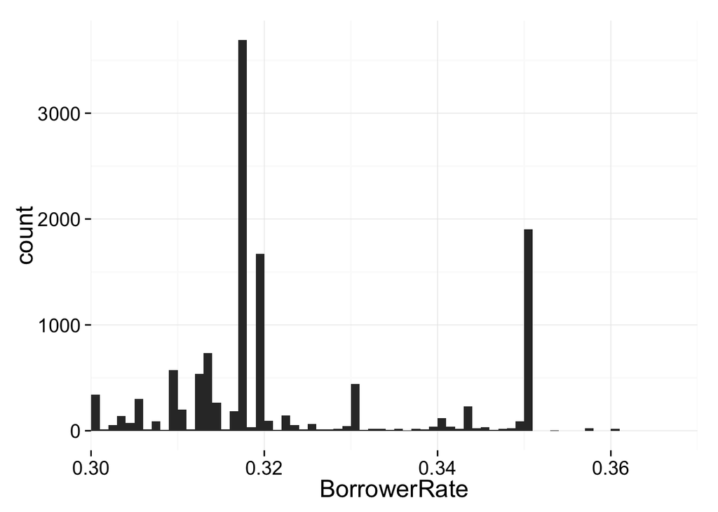

[output not shown]

Now, more specifically in the range 31.5% and 32%.

```
##
##  0.316 0.3165 0.3166 0.3169  0.317 0.3174 0.3175 0.3176 0.3177 0.3178
##    121     60      1      1      2      3      9      2   3672      1
## 0.3179  0.318 0.3185 0.3188 0.3189  0.319 0.3195 0.3197 0.3198 0.3199
##      2      1     27      5      2      4     12      1      3   1651
```

Curiously there is a huge concentration at 31.77% and 31.99%. Let me see when those loan were took.

```
## stat_bin: binwidth defaulted to range/30. Use 'binwidth = x' to adjust this.
```

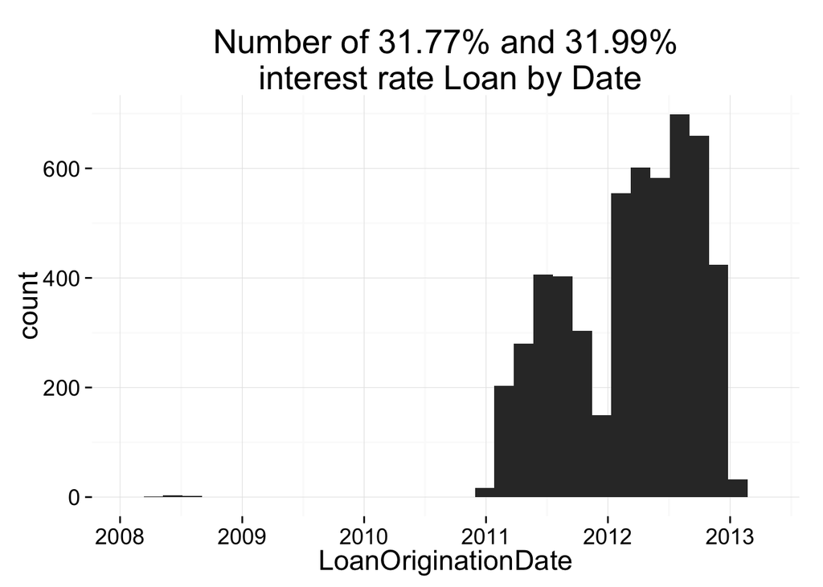

```
##
##   36
## 5323
```

Interesting, all loans with these interest rates have a term of 36 months. Let`s see how the rates are distributed by Term.

```
## stat_bin: binwidth defaulted to range/30. Use 'binwidth = x' to adjust this.
```

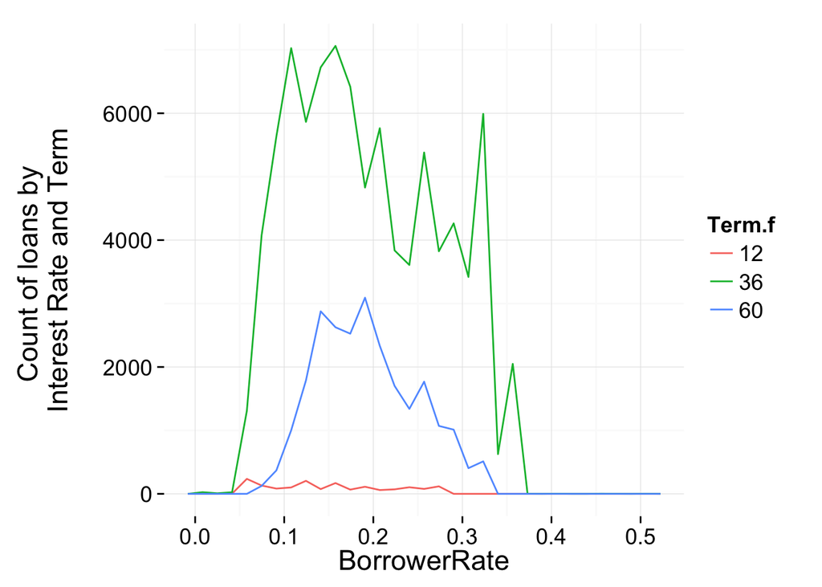

```r
theme_set(theme_minimal(17))

ggplot(aes(x = BorrowerRate), data = d) +
  geom_freqpoly(aes(color = Term.f)) +
  scale_x_continuous() + #limits = c(0, 1000), breaks = seq(0, 1000, 50)
  xlab('BorrowerRate') +
  ylab('Count of loans by \nInterest Rate and Term\n')
```

The most of loans have a term of 36 months. It is curious to see that just loans with term of 36 months have a more dispersed distribution. However, it is difficult to see how the how loans with term of 12 months are distributed. Bellow are the Box plots.

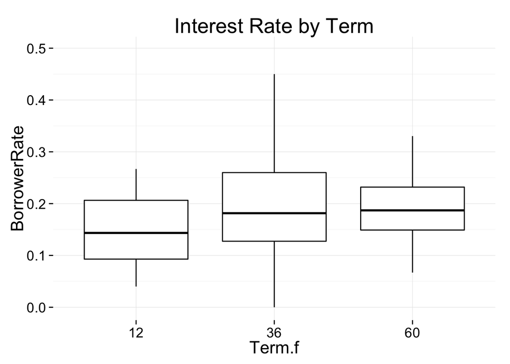

```r
theme_set(theme_minimal(17))

ggplot(aes(x = Term.f, y = BorrowerRate), data = d) +
  scale_color_brewer(type = 'div') +
  geom_boxplot(outlier.size = 0, color = "black") +
  ggtitle('Interest Rate by Term')
```

As previously observed on the frequency polygons , the box plot confirms that 36-months loans are more dispersed. Additionally, I can notice that the median increases sharply from 12 to 36 months and then increases lightly to 60 months. It makes sense, once that a long-term loan is much more unpredictable than a 12 months loan.

Following my reasoning, if the borrower rate are dispersed, I would expectedthat the Risk Score also was dispersed, given that the interest rate should be a function of the risk score. First, let me see the quartiles of the Prosper Rating.

```r
table(d$ProsperRating..numeric., useNA = 'ifany')
```

```
##
##     1     2     3     4     5     6     7  <NA>
##  6935  9795 14274 18345 15581 14551  5372 29084
```

```r
summary(d$ProsperRating..numeric., useNA = 'ifany')
```

```
##    Min. 1st Qu.  Median    Mean 3rd Qu.    Max.    NA's
##   1.000   3.000   4.000   4.072   5.000   7.000   29084
```

As I can see, the risk scores are discrete and ordered. I believe that it is not a issue, given that a averate rate of, for instance, 5.3, has a meaning. It tells me that there is more data point on 5 than in 6. I also notice that there are many data point without a risk score. Below is a histogram just including those that has a score setted:

```
## stat_bin: binwidth defaulted to range/30. Use 'binwidth = x' to adjust this.
```

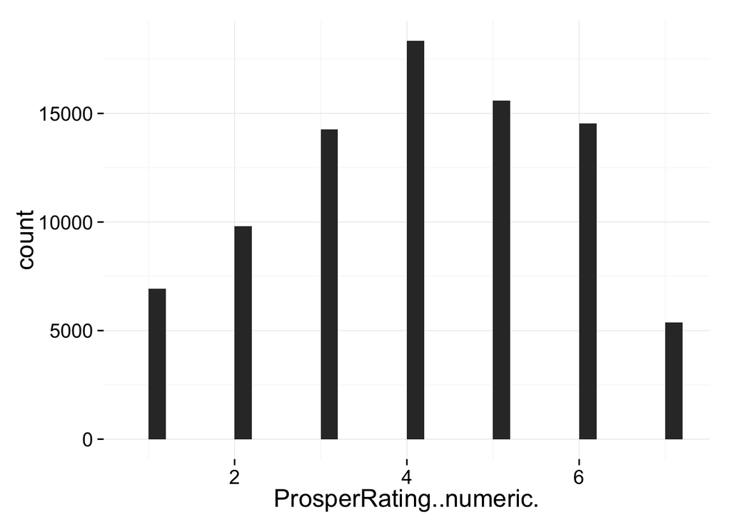

```r
theme_set(theme_minimal(17))

ggplot(aes(x = ProsperRating..numeric.),
       data = subset(d,!is.na(ProsperRating..numeric.) )) +
  geom_histogram()
```

Well…They are not dispersed….and, thinking again, actually they shouldn’t be. The risk score is discrete, there is no way to be dispersed. I would need verify the distribution splitting the data by term, but I will check it later. Maybe the income can help me understand something:

```r
summary(d$StatedMonthlyIncome, useNA = 'ifany')
```

```
##    Min. 1st Qu.  Median    Mean 3rd Qu.    Max.
##       0    3200    4667    5608    6825 1750000
```

```r
summary(d$IncomeRange, useNA = 'ifany')
```

```
##             $0      $1-24,999      $100,000+ $25,000-49,999 $50,000-74,999
##            621           7274          17337          32192          31050
## $75,000-99,999  Not displayed   Not employed
##          16916           7741            806
```

```r
theme_set(theme_minimal(17))

summary(d$IncomeRange, useNA = 'ifany')
```

```
##             $0      $1-24,999      $100,000+ $25,000-49,999 $50,000-74,999
##            621           7274          17337          32192          31050
## $75,000-99,999  Not displayed   Not employed
##          16916           7741            806
```

```r
summary(d$StatedMonthlyIncome, useNA = 'ifany')
```

```
##    Min. 1st Qu.  Median    Mean 3rd Qu.    Max.
##       0    3200    4667    5608    6825 1750000
```

```
## stat_bin: binwidth defaulted to range/30. Use 'binwidth = x' to adjust this.
```

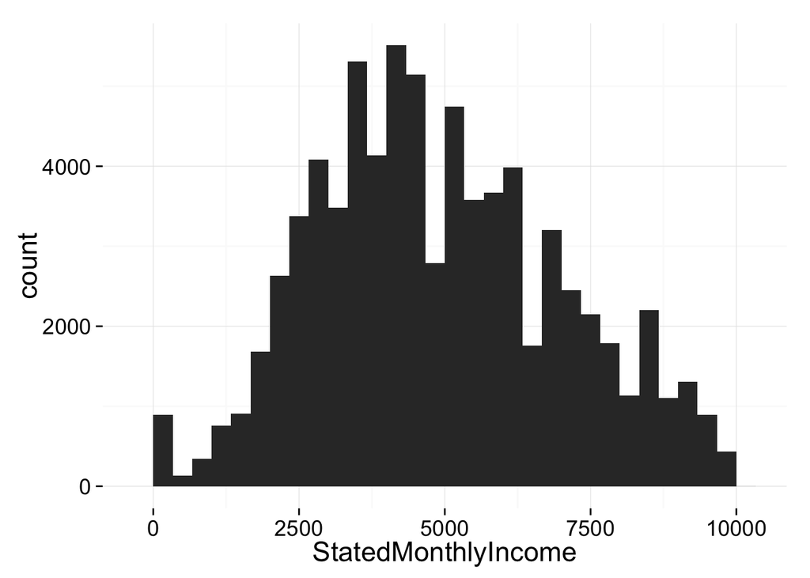

```r
ggplot(aes(x = StatedMonthlyIncome),
       data = subset(d, d$StatedMonthlyIncome < 10000 &
                       !is.na(ProsperRating..numeric.))) +
  geom_histogram()
```

It doesn’t add up much to my thoughts. I believe that this variables have to be related to another to be more meaningful.

Also, I didn’t find nothing so interesting about risk score and income level, two variable that I was expecting more. On the other hand, maybe this variables have more to tell when related to others. I would like to understand better the spike of interest rate previously mentioned and why loans with term of 36-months are more dispersed than 60 months. Also I want to find out why risky loans are classified that way.

# Look at some transformation stuffs to see if it is applyable here

### Analyzing One Variable

Reflection:

-Observing the values that your variable take, like missing values, distribution and outliers; -Boxplot, frequency polygons and histograns are the basic and most important tools to undertand individual variable; -We use transformarmations like log, square and booleans to uncover hidden patterns in the variables;

### Bivariate Section

-Relationship observed -What are the strongest relationship found

### Scatterplot Matrix

Notes:

```r
#
# install.packages('GGally')
#
# library(GGally)
#
# set.seed(1836)
# pf_subset <- pf[,c(2:15)]
# names(pf_subset)
# ggpairs(pf_subset[sample.int(nrow(pf_subset), 1000), ])
#
```

### Alpha and Jitter

Notes:

```r
# Examine the relationship between friendships_initiated (y) and age (x)
# using the ggplot syntax.

# We recommend creating a basic scatter plot first to see what the distribution
#looks like and then adjusting it by adding one layer at a time.

# What are your observations about your final plot?

# Remember to make adjustments to the breaks of the x-axis and to use apply
# alpha and jitter.
# names(pf)

# p1 <- ggplot(aes(x = age, y = friend_count), data = pf) +
#   geom_point(alpha = 1/20, position = position_jitter( h = 0)) +
#   coord_trans(y = "sqrt") +
#   xlim(13, 90)
#
# p2 <- ggplot(aes(x = age, y = friendships_initiated), data = pf) +
#   geom_point(alpha = 1/20, position = position_jitter( h = 0)) +
#   coord_trans(y = "sqrt") +
#   xlim(13, 90)
#
#
# grid.arrange(p1, p2, ncol=1)
```

### Conditional Means

Notes:

```r
#grouping data
# age_groups <- group_by(pf, age)
# pf.fc_by_age <- summarise(age_groups,
#           friend_count_mean = mean(friend_count),
#           fries_count_median = median(friend_count),
#           n = n()
#           )
# head(pf.fc_by_age)
# #as my dataframe is not arranged...
# pf.fc_by_age <- arrange(pf.fc_by_age, age)
# head(pf.fc_by_age)
#
#
# #doing the same
#
# pf.fc_by_age <- pf %>%#channing function
#   group_by(age) %>%
#   summarise(friend_count_mean = mean(friend_count),
#           fries_count_median = median(friend_count),
#           n = n()) %>%
#           arrange(age)
# head(pf.fc_by_age)
```

### Overlaying Summaries with Raw Data

Notes:

```r
# ggplot(aes(x = age, y = friend_count), data = pf) +
#   coord_cartesian(xlim = c(13, 90),
#                   ylim = c(0,2000)) +
#   geom_point(alpha = 0.05,
#             position = position_jitter(h=0),
#             color = 'orange') +
#   geom_line(stat = 'summary', fun.y = mean) +
#   geom_line(stat = 'summary', fun.y = quantile, prob = .1,
#             linetype = 2, color = "blue") +
#   geom_line(stat = 'summary', fun.y = quantile, prob = .9,
#             linetype = 2, color = "blue")
```

### Strong Correlations

Notes:

```r
# ggplot(aes(x = www_likes_received, y = likes_received), data = pf) +
#   geom_point() +
#   xlim (0, quantile(pf$www_likes_received, 0.95)) +
#   ylim(0,quantile(pf$likes_received, 0.95)) +
#   geom_smooth(method = 'lm', color =  'red')
```

What’s the correlation betwen the two variables? Include the top 5% of values for the variable in the calculation and round to 3 decimal places.

```r
# with(pf, cor.test(www_likes_received, likes_received))
```

### Making Sense of Data

Notes:

```r
#
# range(Mitchell$Month)
#
# ggplot(aes(y = Temp, x = Month), data = Mitchell) +
#   geom_point() +
#   scale_x_discrete(breaks = seq(0, 203,12))
#
#
# ggplot(aes(x=(Month%%12),y=Temp),data=Mitchell)+
#   geom_point()
```

### Noise in Conditional Means

```r
# p1 <- ggplot(aes(x = age_with_months, y = friend_count_mean),
#              data = subset(pf.fc_by_age_months, age_with_months < 71)) +
#   geom_line() +
#   geom_smooth()
#
#
# p2 <- ggplot(aes(x = age, y = friend_count_mean),
#              data = subset(pf.fc_by_age, age < 71)) +
#   geom_line() +
#   geom_smooth()
#
#
# p3 <- ggplot(aes(x = round(age/5)*5, y = friend_count_mean),
#              data = subset(pf.fc_by_age, age < 71)) +
#   geom_line()
#
# library(gridExtra)
# grid.arrange(p3, p2,p1,ncol=1)
```

### create a new data frame containing info on diamonds by clarity

Notes:

### Create a bar plot of dplying data

Notes:

We think something odd is going here. These trends seem to go against our intuition.

We encourage you to look into the mean price across cut.

### Analyzing Two Variables

Reflection:

-sccater plots and conditional means; -the bennefits and limitations of use of correlation and how correlation can affect your decision on including the variables in you final model (do not use variables without monotonic behaviour…that influence each other); -we learned how to make sense of our data adjusting our visualizations…we learned how jitter and alpha reduce overplotting;

### Multivariate Section

-Relationship observed -Any surprise?

### Histograms Revisited

Notes:

```r
#
# yo <- read.csv('yogurt.csv')
# str(yo)
#
# #change the id from an int to a factor
# yo$id <- factor(yo$id)
# str(yo)
#
# ggplot(data = yo, aes(x = price)) +
#   geom_histogram()
#
# ggplot(data = yo, aes(x = price)) +
#   geom_histogram(binwidth=10)
#
#
# summary(yo$price)
#
# unique(yo$price)
#
# length(unique(yo$price))
```